# Lecture 26: Inference about a population proportion

Chapter 19

Corinne Riddell (Instructor: Tomer Altman)

October 29, 2025

# Recap

- So far we’ve learned the $z$-test and the $t$-test that apply when the variable of interest is continuous
- We applied these tests to one-sample (e.g., $H_0: \mu=8$) and two-sample settings (e.g., $H_0: \mu_1 = \mu_2$)
- Today, we will generalize these procedures to binary data, for which we estimate a proportion $\hat{p}$ from a sample and use that as our best guess of the underlying population parameter $p$
- Notation: $\bar{x}$ is to $\mu$ as $\hat{p}$ is to $p$

# Agenda

- Confidence interval for a proportion
- Sample size estimates for a proportion
- Hypothesis tests for a proportion

# Recall the sampling distribution for $\hat{p}$

The sampling distribution for $\hat{p}$ is centered on $p$ with a standard error of $\sqrt{\frac{p(1-p)}{n}}$

If we follow the same format for the CI from previous chapters we would get:

$$\hat{p} \pm z^*
\sqrt{\frac{\hat{p}(1-\hat{p})}{n}}$$
This is what is known as the **large sample confidence interval for a population proportion**, or the Wald interval.

# Check your understanding!

# But…

- This confidence interval can perform poorly, meaning that if we repeated the confidence interval 100 times (based on 100 random samples), the coverage could be what is termed
  - overly conservative (e.g., coverage significantly above 95%), or
  - anti-conservative, or permissive, or “poor coverage”
    - Fewer than 95 out of 100 of the 95% confidence intervals, on average, would contain the true value for the proportion $p$
  - For the Wald interval, for different combinations of $p$ and $n$, it can exhibit **both** problems!
- To overcome this, we will modify how we calculate the confidence interval slightly using what is known as the “plus four” method

# Introducing: the “Plus Four” Method

- If you add two imaginary successes and two failures to the data set (increasing the sample size by four imaginary trials), the interval can have better performance
- Let $\tilde{p} = \frac{\text{number of successes + 2}}{n+4}$
- Let $SE = \sqrt{\frac{\tilde{p}(1-\tilde{p})}{n+4}}$
- Then the CI is:
  $$\tilde{p} \pm z^*
  \sqrt{\frac{\tilde{p}(1-\tilde{p})}{n+4}}$$
- This is called the **“Plus Four” Method**
- Note we use $z^*$ rather than $t^*$. This is because the standard error of the sampling distribution is completely determined by $p$ and $n$, we don’t need to estimate a second parameter
- In addition, for smaller samples (when one cannot rely on the CLT), one can rely on alternative methods to get inference that do not rely on Normality of $\hat{p}$
- Use this method when $n \geq 10$

# Why does the “Plus Four” Method work?

- It is a simplification of a more complex method known as the Wilson Score Interval
- You don’t need to know why it works, just that it is better to use this “plus four” trick if you’re making a confidence interval for a proportion by hand
- Note: if the number of successes and failures is relatively large, then the “plus four” method will converge with the large sample Wald CI method

# Two methods so far…

We have so far introduced the large sample method to calculate the CI for p:

$$\hat{p} \pm z^*
\sqrt{\frac{\hat{p}(1-\hat{p})}{n}}$$
And the plus four method to calculate the CI for p:

- $\tilde{p} = \frac{\text{number of successes + 2}}{n+4}$
- Let $SE = \sqrt{\frac{\tilde{p}(1-\tilde{p})}{n+4}}$
- Then the CI is:
  $$\tilde{p} \pm z^*
  \sqrt{\frac{\tilde{p}(1-\tilde{p})}{n+4}}$$

We are going to talk about two more methods.

# What does R use?

- R has two functions to calculate confidence intervals for proportions
- The first function is `prop.test` (analogous to `t.test`) to calculate confidence intervals and hypothesis tests for binomial proportions
- This function uses the **Wilson score** method, specifically, the “Wilson score interval with a continuity correction”.
  - Thus, you don’t need to “plus 4” the proportion or standard error
  - It will do it for you
  - It does an even better job because of the continuity correction
  - You do not need to know how to calculate the Wilson score method by hand
  - You only need to know how to use R to perform this method.

# What does R use?

- There is a fourth often-used method to compute confidence intervals for proportions called the **Clopper Pearson method**
  - Also known as the **“Exact method”**
  - Implemented with the second R function, `binom.test()`
- The exact method is statistically conservative, meaning that it gives better coverage than it suggests
  - A 95% CI computed under this method includes the true proportion in the interval more than 95% of the time
- It can be thought of as an inversion of hypothesis testing
  - It finds the set of all values of the parameter $p_0$, where we consider the null value in a two-sided hypothesis test, would lead to a $p$-value $p \ge 0.05$
  - It calculates the $p$-value using the binomial distribution function
  - As a reminder, this was the cumulative probability function for binomial (Lec 16):

$$P(X \leq x)=\sum_{i=0}^x {n \choose
i}p_0^i(1-p_0)^{n-i}$$

- Generally, exact methods are considered the gold-standard for making confidence intervals as they provide the stated coverage with no asymptotic assumptions (that is, do not rely on Normal sampling distributions for the estimator, in this case, $\hat{p}$)

# Example applying all the methods

Suppose that 500 elderly individuals suffered hip fractures, of which 100 died within a year of their fracture. Compute the 95% CI for the proportion who died using:

- the large sample Wald method
- the “plus four” method (by hand)
- the Wilson Score method (using `prop.test`)
- the Clopper Pearson Exact method (using `binom.test`)

# Example of large sample Wald method to calculate the CI for a proportion (by hand)

```r
p.hat <- 100/500 # estimate proportion
se <- sqrt(p.hat*(1-p.hat)/500) # standard error
p.hat - 1.96*se # Lower confidence bound
```

```
## [1] 0.1649385
```

```r
p.hat + 1.96*se # Upper confidence bound
```

```
## [1] 0.2350615
```

- Our estimate for the proportion is $\hat{p}=20\%$
- Using the large sample Wald method, the 95% confidence interval is 16.5% to 23.5%
- Remember, this method has poor coverage, meaning that fewer than 95 of the 100 intervals we would make would contain the true value $p$ on average

# Example using the “plus four” method to calculate the CI for a proportion (by hand)

```r
p.tilde <- (100 + 2)/(500 + 4)
se <- sqrt(p.tilde * (1 - p.tilde)/(500 + 4)) # standard error
p.tilde - 1.96 * se # Lower confidence bound
```

```
## [1] 0.1673039
```

```r
p.tilde + 1.96 * se # Upper confidence bound
```

```
## [1] 0.237458
```

Using the plus 4 method, the confidence interval is 16.7% to 23.7%.

# Example using the Wilson Score method to calculate the CI for a proportion (using R)

```r
prop.test(x = 100, n = 500, conf.level = 0.95)
```

```
##
##  1-sample proportions test with continuity correction
##
## data:  100 out of 500, null probability 0.5
## X-squared = 178.8, df = 1, p-value < 2.2e-16
## alternative hypothesis: true p is not equal to 0.5
## 95 percent confidence interval:
##  0.1663581 0.2383462
## sample estimates:
##   p
## 0.2
```

- The 95% confidence interval using the Wilson Score method is 16.6% to 23.8%
- Note that the `prop.test` function is also conducting a two-sided hypothesis test (where $H_0: p_0=0.5$, unless otherwise specified)
- You can ignore the testing-related output and focus on the CI output when using the function to make a CI

# Example using the Clopper Pearson “Exact” method to calculate the CI for a proportion (using R)

```r
binom.test(x = 100, n = 500, conf.level = 0.95)
```

```
##
##  Exact binomial test
##
## data:  100 and 500
## number of successes = 100, number of trials = 500, p-value < 2.2e-16
## alternative hypothesis: true probability of success is not equal to 0.5
## 95 percent confidence interval:
##  0.1658001 0.2377918
## sample estimates:
## probability of success
##                    0.2
```

- The 95% confidence interval using the exact binomial test is 16.6% to 23.8%
- Note that this interval is wider than the one made with the large sample Wald method
  - It has larger coverage (contains the true value more often) which necessitates a wider interval
- Note that the `binom.test` function is also conducting a two-sided hypothesis test (where $H_0: p_0=0.5$, unless otherwise specified)
- You can ignore the testing-related output and focus on the CI output

# Summary of the confidence intervals across the methods

| Method | 95% Confidence Interval | R Function |
| --- | --- | --- |
| Large sample Wald | 16.5% to 23.5% | by hand |
| Plus four | 16.7% to 23.7% | by hand |
| Wilson Score* | 16.6% to 23.8% | `prop.test` |
| Clopper Pearson** | 16.6% to 23.8% | `binom.test` |

*with continuity correction

**also known as the exact method

- Only the large sample Wald method is symmetric around $\hat{p} = 20\%$. This is okay. Symmetric confidence intervals are applicable to Normal sampling distributions, which might or might not describe the distribution of $\hat{p}$
- Non-symmetric CIs make sense because $p$ is bounded between 0 and 1. For example, if $p$ is very small, say 0.012, you would not want a CI that has a lower bound which is negative, this would not make sense
- When the Normal approximation assumptions are satisfied, the methods give very similar results

# Another example of the “plus four” method (by hand)

[We are including another example for you to read so you can practice working out the calculations by hand.]

A study examined a random sample of 75 SARS patients, of which 64 developed recurrent fever.

Therefore $\hat{p}=64/75=85.33\%$

Using the plus 4 method: $\tilde{p}=\frac{64 + 2}{75+4} = 83.54\%$

# How big should the sample be to estimate a proportion?

Suppose that you want to estimate a sample size for a proportion within a given margin of error. That is, you want to put a maximum bound on the width of the corresponding confidence interval.

Let $m$ denote the desired margin of error. Then $m = z^*\sqrt{\frac{\hat{p}(1-\hat{p})}{n}}$

We can solve this equation for $n$, but we also need to plug in a value for $p$. To do that we make a guess for $p$ denoted by $p^*$.

$p^*$ is your best estimate for the underlying proportion. You might gather this estimate from a completed pilot study or based on previous studies published by someone else. If you have no best guess, you can use $p^*=0.5$. This will produce the most conservative estimate of $n$. However if the true $p$ is less than 0.3 or greater than 0.7, the sample size estimated may be much larger than you need.

# How big should the sample be to estimate a proportion?

Rearranging the formula on the last slide for $n$, we get:

$m = z^*\sqrt{\frac{\hat{p}(1-\hat{p})}{n}}$

$\sqrt{n}m=z^*\sqrt{p(1-p)}$

$\sqrt{n}=\frac{z^*}{m}\sqrt{p(1-p)}$

$n = \big(\frac{z^*}{m}\big)^2p^*(1-p^*)$

This last formula is the one we will use to estimate the required sample size.

# Example of estimating sample size

Suppose after the general election, you were interested in estimating the number of STEM undergraduate students who voted. So you want to do a study to estimate this proportion. How many students should you include in your sample?

First you need to decide what margin of error you desire. Suppose it is 4 percentage points or $m=0.04$ for a 95% CI.

If you had no idea what proportion of STEM students voted then you let $p^*=0.5$ and solve for $n$:

$n = (\frac{z^*}{m})^2p^*(1-p^*) = (\frac{1.96}{0.04})^2\times 0.5 \times 0.5 = 600.25 = 601$

This implies you would need to sample 601 students to get an estimate with a 95% confidence interval that is +/- 4 percentage points.

However, suppose you found a previous study that estimated the number of STEM students who voted to be 25%. Then what sample size would you need to detect this proportion?

$n = (\frac{z^*}{m})^2p^*(1-p^*) = (\frac{1.96}{0.04})^2\times 0.25 \times 0.75 = 450.19 = 451$

# Example of estimating sample size

What if you want the width of the 95% confidence interval to be 6 percentage points. What would $m$ be in this case?

# Example of estimating sample size

What if you want the width of the 95% confidence interval to be 6 percentage points. What would $m$ be in this case?

The width of the 95% CI is equal to twice the margin of error. So if you want the width to be 0.06, then this is equivalent to saying you want a margin of error of 0.03.

# Hypothesis tests of a proportion

When you only have one sample what is the null hypothesis? You’re interested in knowing whether there is evidence against the null hypothesis that the population proportion $p$ is equal to some specified value $p_0$. That is:

$$H_0: p = p_0$$

For example, you may want to test whether there is evidence against the null hypothesis that $p = 0.25$.

# Hypothesis tests of a proportion

Recall the sampling distribution for the proportion:

- Normally distributed
- Centered at $p_0$ under the null hypothesis
- Has a standard error of $\sqrt{\frac{p_0(1-p_0)}{n}}$

# Hypothesis tests of a proportion

The test statistic for the null hypothesis is:

$$z =
\frac{\hat{p}-p_0}{\sqrt{\frac{p_0(1-p_0)}{n}}}$$
This is a $z$-test (not a $t$-test) so we compare to the standard Normal distribution and ask what is the probability of observing a $z$ value of this magnitude (or more extreme).

# Hypothesis tests of a proportion

One sided alternatives:

- $H_a: p > p_0$
- $H_a: p < p_0$

Two-sided alternative:

- $H_a: p \ne p_0$

When to use this test? Use this test when the expected number of successes and failures is $\geq$ 10. That is, when $np_0\geq10$ and $n(1-p_0)\geq 10$.

# Example of a hypothesis test for a proportion

Consider an SRS of 200 patients undergoing treatment to alleviate side effects from a rigorous drug regimen at a particular hospital, where 33 patients experienced reduced or no side effects.

$\hat{p}=33/200=0.165=16.5\%$

Suppose that historically, the rate of patients with little or no side effects is 10%. Does the new treatment increase the rate? That is:

$H_0: p = 0.10$

$H_a: p > 0.10$

# Example of a hypothesis test for a proportion

Step 1: Calculate $\hat{p} = 16.5\%$ from previous slide.

Step 2: Calculate the standard error of the sampling distribution for $p$ under the null hypothesis: $SE = \sqrt{\frac{p_0(1-p_0)}{n}} = \sqrt{\frac{0.1(1-0.1)}{200}} = 0.0212132$

Step 3: Calculate the $z$-test for the proportion:

$z = \frac{\hat{p}-p_0}{\sqrt{\frac{p_0(1-p_0)}{n}}} = \frac{0.165-0.10}{0.0212132} = 3.06413$

Step 4: Calculate the probability of seeing a $z$-score of this magnitude *or larger*:

```r
pnorm(q = 3.06413, lower.tail = F)
```

```
## [1] 0.00109152
```

Step 5: Evaluate the evidence against the null hypothesis. Because the $p$-value is so small (0.1%), there is little chance of seeing a proportion equal to 16.5% or larger if the true proportion is actually 10%. Thus, there is evidence in favor of the alternative hypothesis, that the underlying proportion is larger than 10%.

# Another Example

Suppose that there were 100 elderly individuals with falls observed, and 2 died. Here are the 95% CIs applying the four different methods:

[output not shown]

*with continuity correction

We can graphically compare the CIs from the previous slide:

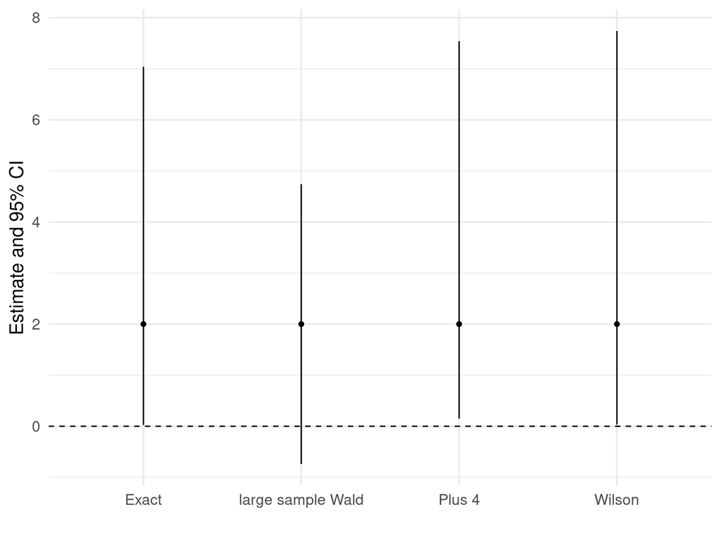

# Elderly falls example

Findings:

- Notice how different the intervals are, especially large sample Wald vs. others
- Notice that the large sample Wald lower bound is nonsensical (i.e., we can’t have negative proportions!)
- The large sample Wald CI differs from the others because the Normal approximation assumptions are not satisfied

# Code for elderly falls example

```r
p.hat <- 2/100 # estimate proportion
se <- sqrt(p.hat*(1-p.hat)/100) # standard error
c(p.hat - 1.96*se, p.hat + 1.96*se) # CI
```

```
## [1] -0.00744  0.04744
```

```r
binom.test(x = 2, n = 100, p = 0.5, conf.level = 0.95)
```

```
##
##  Exact binomial test
##
## data:  2 and 100
## number of successes = 2, number of trials = 100, p-value < 2.2e-16
## alternative hypothesis: true probability of success is not equal to 0.5
## 95 percent confidence interval:
##  0.002431337 0.070383932
## sample estimates:
## probability of success
##                   0.02
```

```r
prop.test(x = 2, n = 100, p = 0.5, conf.level = 0.95)
```

```
##
##  1-sample proportions test with continuity correction
##
## data:  2 out of 100, null probability 0.5
## X-squared = 90.25, df = 1, p-value < 2.2e-16
## alternative hypothesis: true p is not equal to 0.5
## 95 percent confidence interval:
##  0.003471713 0.077363988
## sample estimates:
##    p
## 0.02
```

```r
p.tilde <- (2 + 2)/(100 + 4)
se <- sqrt(p.tilde*(1-p.tilde)/(100 + 4)) # standard error
c(p.tilde - 1.96*se, p.tilde + 1.96*se) # CI
```

```
## [1] 0.00150119 0.07542189
```

# Check your understanding!

# Recap

- The binomial distribution has all of the same statistical “procedures”:
  - Confidence intervals
  - Sample size estimation
  - Hypothesis testing
- However, there are problems with the coverage of the CIs:
  - Subtle interactions between discrete binomial distribution and Normal-based approximations
  - Use “Plus 4” method when calculating “by hand” and sample is “small”
  - Use `prop.test` when using R functions
  - The coverage problem goes away as the sample size gets larger, and more of the Normality assumptions are met